# alex-hw1-html.rmd

## Question 1: Building a DAG (5 points)

### 1.1

Write out the factorization of the joint distribution implied by the DAG using mathematical notation. (1 point)

$P(A, E, S, O, R, T) == P(A)P(S)P(E|A,S)P(O|E)P(R|E)P(T|O,R)$

### 1.2

Rewrite the above factorization in *bnlearn*’s string representation. (1 point)

```r
dagStr <- "[A][S][E|A:S][O|E][R|E][T|O:R]"
```

### 1.3

Use this to create a DAG in *bnlearn*. (1 point)

```r
dag <- model2network(dagStr)
```

### 1.4

Print the class of the DAG object. (1 point)

```r
class(dag)
```

```
## [1] "bn"
```

### 1.5

Use `graphviz.plot` to plot the DAG. (1 point)

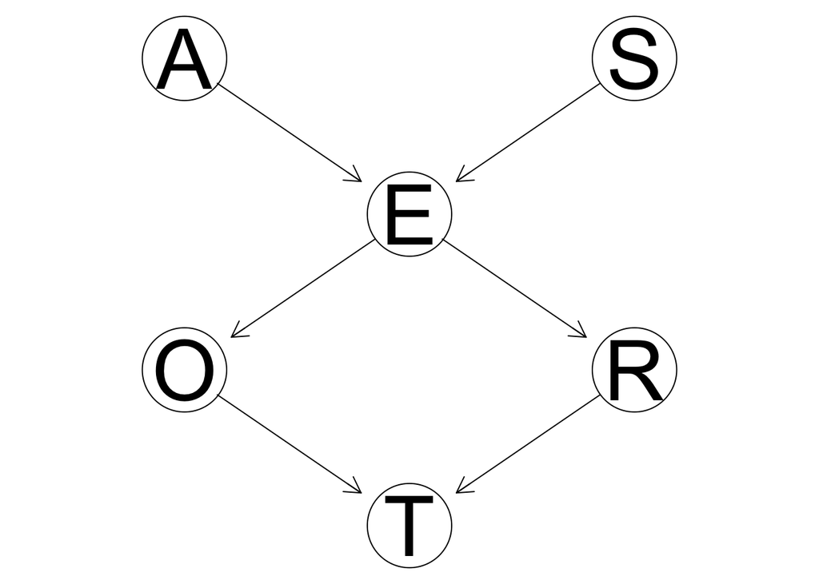

```r
graphviz.plot(dag)
```

## Question 2: Experimenting with graph utilities (5 points)

### 2.1

Extract and print the nodes and arcs of the DAG you created in previous questions. (1 point)

```r
nodes(dag)
```

```
## [1] "A" "E" "O" "R" "S" "T"
```

```r
arcs(dag)
```

```
##      from to
## [1,] "A"  "E"
## [2,] "S"  "E"
## [3,] "E"  "O"
## [4,] "E"  "R"
## [5,] "O"  "T"
## [6,] "R"  "T"
```

### 2.2

Extract and print the parents and the children of each node using `parents` and `children` functions. (1 point)

```r
for(n in nodes(dag)) {
  cat(n, "'s parents are: '", parents(dag,n), "'.  ")
  cat(n, "'s children are: '", children(dag,n), "'")
  cat("\n")
}
```

```
## A 's parents are: '  '.  A 's children are: ' E '
## E 's parents are: ' A S '.  E 's children are: ' O R '
## O 's parents are: ' E '.  O 's children are: ' T '
## R 's parents are: ' E '.  R 's children are: ' T '
## S 's parents are: '  '.  S 's children are: ' E '
## T 's parents are: ' O R '.  T 's children are: '  '
```

### 2.3

Use the `mb` function to extract the Markov blanket of A, E, and T. (1 point)

```r
mb(dag, "A")
```

```
## [1] "E" "S"
```

```r
mb(dag, "E")
```

```
## [1] "A" "O" "R" "S"
```

```r
mb(dag, "T")
```

```
## [1] "O" "R"
```

### 2.5

Describe, in terms of coniditional independence (NOT in terms of the DAG) the definition of a Markov blanket. (1 point)

If M = Markov Blanket of variable Y from set of random variables S then Y when conditioned on M is indpendent on any subset X of set S provided $X \bigcap M=\emptyset$

## Question 3: Conditional probability distribution (CPD) parameter estimation (5 points)

Bayesian network = DAG + CPD with specified parameters

### 3.1

Fit the parameters of the DAG from the data stored in survey2.txt using Bayesian estimation, and save the result into an object of class bn.fit. (2 points)

```r
survey <- read.table("/Users/alex/i/causalML/HW/hw1_release/survey2.txt", header = TRUE)
survey[] <- lapply(survey, function(x) as.factor(x))
bn.bayesDefault <- bn.fit(dag, data = survey, method = "bayes")
```

### 3.2

Play with the Bayesian prior parameter **iss** and report the changes in the parameters learned from Bayesian network. Explain the changes. (3 points)

```r
sink("bn.bayes_iss_default")
bn.fit(dag, data = survey, method = "bayes")
```

```
##
##   Bayesian network parameters
##
##   Parameters of node A (multinomial distribution)
##
## Conditional probability table:
##      adult       old     young
## 0.3575391 0.1578417 0.4846193
##
##   Parameters of node E (multinomial distribution)
##
## Conditional probability table:
##
## , , S = F
##
##       A
## E          adult       old     young
##   high 0.6389365 0.8446809 0.1558105
##   uni  0.3610635 0.1553191 0.8441895
##
## , , S = M
##
##       A
## E          adult       old     young
##   high 0.7191617 0.8913043 0.8099825
##   uni  0.2808383 0.1086957 0.1900175
##
##
##   Parameters of node O (multinomial distribution)
##
## Conditional probability table:
##
##       E
## O            high        uni
##   emp  0.98016416 0.96531303
##   self 0.01983584 0.03468697
##
##   Parameters of node R (multinomial distribution)
##
## Conditional probability table:
```

[output cut: 16 more lines]

```
## , , R = big
##
##        O
## T              emp       self
##   car   0.71084719 0.68553459
##   other 0.13887569 0.15723270
##   train 0.15027712 0.15723270
##
## , , R = small
##
##        O
## T              emp       self
##   car   0.54655295 0.72549020
##   other 0.07746979 0.25490196
##   train 0.37597726 0.01960784
```

```r
sink()

sink("bn.bayes_iss_1")
bn.fit(dag, data = survey, method = "bayes", iss=1)
```

```
##
##   Bayesian network parameters
##
##   Parameters of node A (multinomial distribution)
##
## Conditional probability table:
##      adult       old     young
## 0.3575391 0.1578417 0.4846193
##
##   Parameters of node E (multinomial distribution)
##
## Conditional probability table:
##
## , , S = F
##
##       A
## E          adult       old     young
##   high 0.6389365 0.8446809 0.1558105
##   uni  0.3610635 0.1553191 0.8441895
##
## , , S = M
##
##       A
## E          adult       old     young
##   high 0.7191617 0.8913043 0.8099825
##   uni  0.2808383 0.1086957 0.1900175
##
##
##   Parameters of node O (multinomial distribution)
##
## Conditional probability table:
##
##       E
## O            high        uni
##   emp  0.98016416 0.96531303
##   self 0.01983584 0.03468697
##
##   Parameters of node R (multinomial distribution)
##
## Conditional probability table:
```

[output cut: 16 more lines]

```
## , , R = big
##
##        O
## T              emp       self
##   car   0.71084719 0.68553459
##   other 0.13887569 0.15723270
##   train 0.15027712 0.15723270
##
## , , R = small
##
##        O
## T              emp       self
##   car   0.54655295 0.72549020
##   other 0.07746979 0.25490196
##   train 0.37597726 0.01960784
```

```r
sink()

sink("bn.bayes_iss_5")
bn.fit(dag, data = survey, method = "bayes", iss=5)
```

```
##
##   Bayesian network parameters
##
##   Parameters of node A (multinomial distribution)
##
## Conditional probability table:
##      adult       old     young
## 0.3573935 0.1588972 0.4837093
##
##   Parameters of node E (multinomial distribution)
##
## Conditional probability table:
##
## , , S = F
##
##       A
## E          adult       old     young
##   high 0.6379898 0.8389121 0.1568266
##   uni  0.3620102 0.1610879 0.8431734
##
## , , S = M
##
##       A
## E          adult       old     young
##   high 0.7181168 0.8873418 0.8078261
##   uni  0.2818832 0.1126582 0.1921739
##
##
##   Parameters of node O (multinomial distribution)
##
## Conditional probability table:
##
##       E
## O            high        uni
##   emp  0.97755102 0.96218487
##   self 0.02244898 0.03781513
##
##   Parameters of node R (multinomial distribution)
##
## Conditional probability table:
```

[output cut: 16 more lines]

```
## , , R = big
##
##        O
## T              emp       self
##   car   0.71013118 0.66081871
##   other 0.13924451 0.16959064
##   train 0.15062431 0.16959064
##
## , , R = small
##
##        O
## T              emp       self
##   car   0.54474982 0.65079365
##   other 0.07963354 0.26984127
##   train 0.37561663 0.07936508
```

```r
sink()

sink("bn.bayes_iss_10")
bn.fit(dag, data = survey, method = "bayes", iss=10)
```

```
##
##   Bayesian network parameters
##
##   Parameters of node A (multinomial distribution)
##
## Conditional probability table:
##      adult       old     young
## 0.3572139 0.1601990 0.4825871
##
##   Parameters of node E (multinomial distribution)
##
## Conditional probability table:
##
## , , S = F
##
##       A
## E          adult       old     young
##   high 0.6368243 0.8319672 0.1580882
##   uni  0.3631757 0.1680328 0.8419118
##
## , , S = M
##
##       A
## E          adult       old     young
##   high 0.7168246 0.8825000 0.8051724
##   uni  0.2831754 0.1175000 0.1948276
##
##
##   Parameters of node O (multinomial distribution)
##
## Conditional probability table:
##
##       E
## O            high        uni
##   emp  0.97432432 0.95833333
##   self 0.02567568 0.04166667
##
##   Parameters of node R (multinomial distribution)
##
## Conditional probability table:
```

[output cut: 16 more lines]

```
## , , R = big
##
##        O
## T              emp       self
##   car   0.70923999 0.63440860
##   other 0.13970356 0.18279570
##   train 0.15105645 0.18279570
##
## , , R = small
##
##        O
## T              emp       self
##   car   0.54253835 0.58974359
##   other 0.08228731 0.28205128
##   train 0.37517434 0.12820513
```

```r
sink()

sink("bn.bayes_iss_100")
bn.fit(dag, data = survey, method = "bayes", iss=100)
```

```
##
##   Bayesian network parameters
##
##   Parameters of node A (multinomial distribution)
##
## Conditional probability table:
##      adult       old     young
## 0.3543860 0.1807018 0.4649123
##
##   Parameters of node E (multinomial distribution)
##
## Conditional probability table:
##
## , , S = F
##
##       A
## E          adult       old     young
##   high 0.6187683 0.7425150 0.1793103
##   uni  0.3812317 0.2574850 0.8206897
##
## , , S = M
##
##       A
## E          adult       old     young
##   high 0.6959315 0.8122449 0.7641791
##   uni  0.3040685 0.1877551 0.2358209
##
##
##   Parameters of node O (multinomial distribution)
##
## Conditional probability table:
##
##       E
## O            high        uni
##   emp  0.92289157 0.89855072
##   self 0.07710843 0.10144928
##
##   Parameters of node R (multinomial distribution)
##
## Conditional probability table:
```

[output cut: 16 more lines]

```
## , , R = big
##
##        O
## T             emp      self
##   car   0.6938899 0.4561404
##   other 0.1476104 0.2719298
##   train 0.1584997 0.2719298
##
## , , R = small
##
##        O
## T             emp      self
##   car   0.5093897 0.3908046
##   other 0.1220657 0.3218391
##   train 0.3685446 0.2873563
```

```r
sink()

sink("bn.bayes_iss_1000")
bn.fit(dag, data = survey, method = "bayes", iss=1000)
```

```
##
##   Bayesian network parameters
##
##   Parameters of node A (multinomial distribution)
##
## Conditional probability table:
##      adult       old     young
## 0.3429719 0.2634538 0.3935743
##
##   Parameters of node E (multinomial distribution)
##
## Conditional probability table:
##
## , , S = F
##
##       A
## E          adult       old     young
##   high 0.5512010 0.5656402 0.3021277
##   uni  0.4487990 0.4343598 0.6978723
##
## , , S = M
##
##       A
## E          adult       old     young
##   high 0.5997819 0.6100719 0.6127389
##   uni  0.4002181 0.3899281 0.3872611
##
##
##   Parameters of node O (multinomial distribution)
##
## Conditional probability table:
##
##       E
## O           high       uni
##   emp  0.7028902 0.6729560
##   self 0.2971098 0.3270440
##
##   Parameters of node R (multinomial distribution)
##
## Conditional probability table:
```

[output cut: 16 more lines]

```
## , , R = big
##
##        O
## T             emp      self
##   car   0.5893471 0.3510773
##   other 0.2014605 0.3244613
##   train 0.2091924 0.3244613
##
## , , R = small
##
##        O
## T             emp      self
##   car   0.4014532 0.3398950
##   other 0.2515895 0.3320210
##   train 0.3469573 0.3280840
```

```r
sink()

sink("bn.bayes_iss_1000000")
bn.fit(dag, data = survey, method = "bayes", iss=1000000)
```

```
##
##   Bayesian network parameters
##
##   Parameters of node A (multinomial distribution)
##
## Conditional probability table:
##      adult       old     young
## 0.3333493 0.3332174 0.3334333
##
##   Parameters of node E (multinomial distribution)
##
## Conditional probability table:
##
## , , S = F
##
##       A
## E          adult       old     young
##   high 0.5000810 0.5000810 0.4995356
##   uni  0.4999190 0.4999190 0.5004644
##
## , , S = M
##
##       A
## E          adult       old     young
##   high 0.5001828 0.5001529 0.5001769
##   uni  0.4998172 0.4998471 0.4998231
##
##
##   Parameters of node O (multinomial distribution)
##
## Conditional probability table:
##
##       E
## O           high       uni
##   emp  0.5003507 0.5002748
##   self 0.4996493 0.4997252
##
##   Parameters of node R (multinomial distribution)
##
## Conditional probability table:
```

[output cut: 16 more lines]

```
## , , R = big
##
##        O
## T             emp      self
##   car   0.3341263 0.3333520
##   other 0.3329249 0.3333240
##   train 0.3329488 0.3333240
##
## , , R = small
##
##        O
## T             emp      self
##   car   0.3334333 0.3333400
##   other 0.3332134 0.3333320
##   train 0.3333533 0.3333280
```

```r
sink()
```

### 5.1

Compute and plot the PDAG of the DAG for the survey data using the `cpdag` function. Call this PDAG P1 and the original DAG D1. How does P1 and D1 compare? Explain any similarities or differences. (1 point)

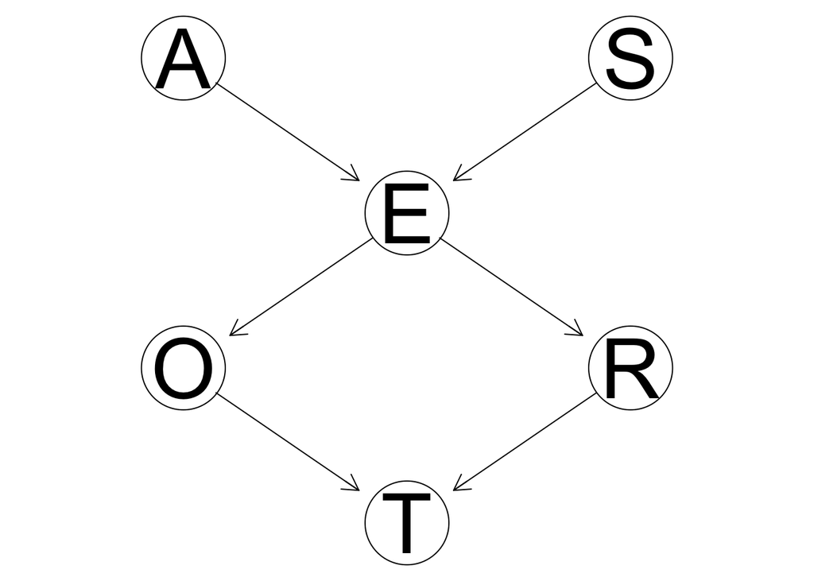

```r
d1 <- dag
p1 <- cpdag(d1)
graphviz.plot(p1)
```

Explanation of result: p1 is identical to d1 because any arrow reversal in p1 would change set of open V-structures: i.e. reversing O->E would create new open V structure: O->E<-A which cannot be found in d1

### 5.2 Create a DAG D2 that is the same as D1 except that it has a new arc from Occupation to Residence. This makes sense because surely somebody’s

job determines where they live (or is it the other way around?). Note that this is a fine example of applying domain knowledge about the data generative process in causal model development. Plot the result with `graphviz.plot`. Now recompute a PDAG P2 from D2. What, if anything, is different between P1 and P2 and what explains these differences or lack of differences? (1 point)

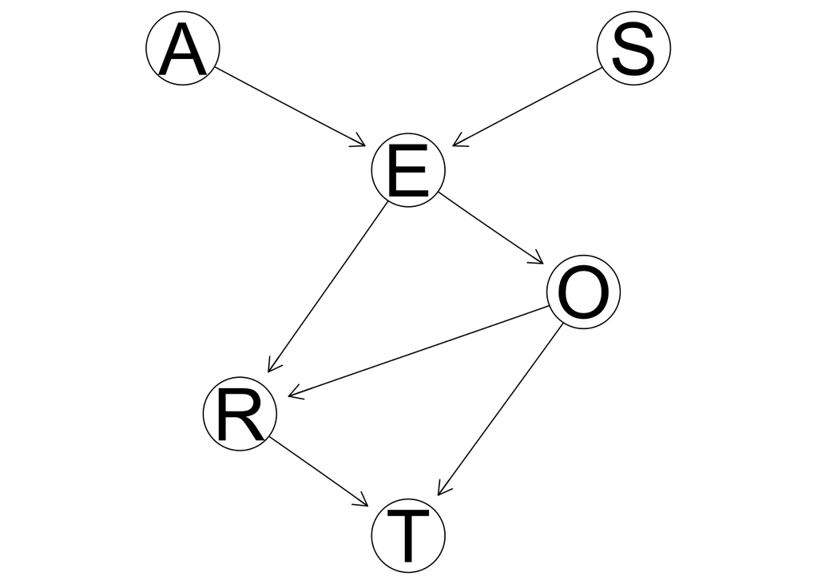

```r
d2 <- model2network("[A][S][E|A:S][O|E][R|E:O][T|O:R]")
graphviz.plot(d2)
```

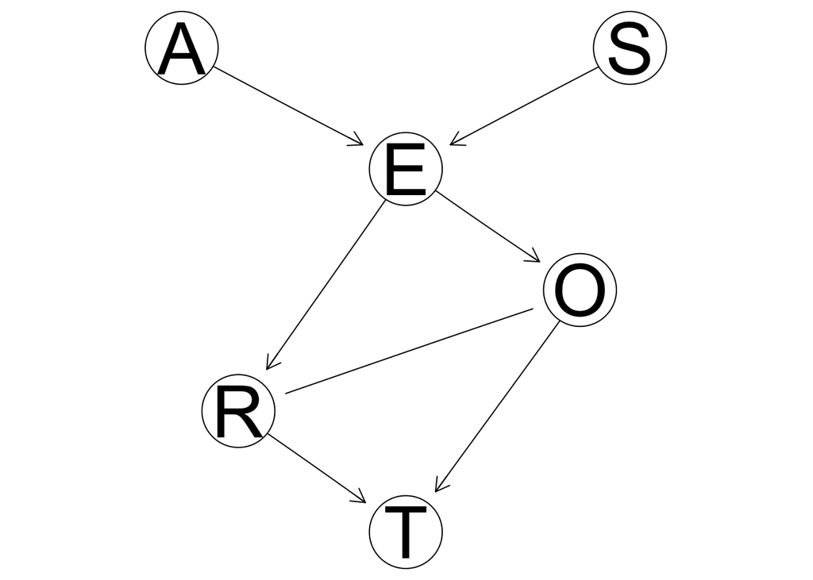

```r
p2 <- cpdag(d2)
graphviz.plot(p2)
```

p1 is different than p2 and differences are:

- skeletal difference, p2 has an extra edge R - O
- Edge R-O has no direction, which meas whatever direction is assigned to it, set of open V-structures remain the same.

### 5.3 Create a third DAG D3 that is different from the second DAG

(with the O->R edge) but is in the same Markov equivalence class. Do this by reasoning about P2 – in other words look at P2 and create another DAG D3, such that `cpdag(D3)` will also produce P2. Plot D3. (1 point)

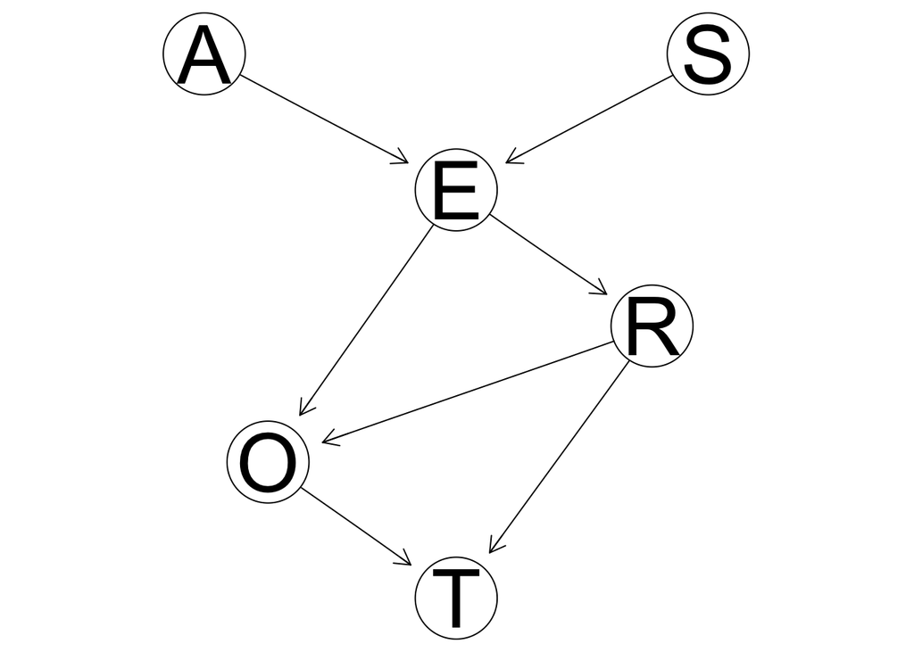

```r
d3 <- model2network("[A][S][E|A:S][O|E:R][R|E][T|O:R]")
graphviz.plot(d3)
```

d3 could be built by assigning different than in d2 direction between O and R (i.e. R->O) , because it is a node in p2 not having any direction (i.e. reversible)

### 5.4

Calculate the log-likelihood of the data given D2 and the log-likelihood of the data given D3. These values should be the same, explain why. You can use the `score` function with the argument `type = 'loglik`, or you can simply se the `logLik` function, which is just a wrapper for `score`. You dont need to provide paramter values for the CPDs of the DAG, `score` will estimate them for you. (1 point)

```r
score(d2, survey, type="loglik")
```

```
## [1] -2350.686
```

```r
score(d3, survey, type="loglik")
```

```
## [1] -2350.686
```

Calculated scores are same because conditional indpendencies extracted from data (“survey2.txt”) could be equally described by both graphs - d2 and d3.

## Question 6: Modeling and Inference using Pyro (18 points)

If you are new to tensor-based frameworks, make sure you give yourself plenty of time for this question. It takes time to get used to debugging. One common source of bugs is integers, *pyro* prefers you use floats (e.g., `torch.tensor(1.0)` instead of `torch.tensor(1)`). If you hit a bug and solve it, why not share with your classmates on Piazza?

### 6.1 Modeling

```python
import torch
import pyro
from pyro.distributions import Categorical
import torch
from collections import Counter

pyro.set_rng_seed(101)

prob_A = torch.tensor([0.36, 0.16, 0.48]) # A=adult, A=old, A=young

prob_S = torch.tensor([0.55, 0.45]) #S=F, S=M

prob_E = torch.tensor([
    [[0.64, 0.36], #E=high|S=F,A=adult, E=uni|S=F,A=adult
    [0.84, 0.16],  #E=high|S=F,A=old,   E=uni|S=F,A=old
    [0.16, 0.84]], #E=high|S=F,A=young, E=uni|S=F,A=young

    [[0.72, 0.28], #E=high|S=M,A=adult, E=uni|S=M,A=adult
    [0.89, 0.11],  #E=high|S=M,A=old,   E=uni|S=M,A=old
    [0.81, 0.19]], #E=high|S=M,A=young, E=uni|S=M,A=young
    ])

prob_O = torch.tensor([
    [0.98, 0.02], #O=emp|E=high,  O=self|E=high
    [0.97, 0.03]  #O=emp|E=uni,   O=self|E=uni
    ])


prob_R = torch.tensor([
    [0.72, 0.28], #R=big|E=high, R=small|E=high
    [0.94, 0.06]  #R=big|E=uni,  R=small|E=uni
    ])

prob_T = torch.tensor([
    [[0.71, 0.14, 0.15], #T=car|R=big,O=emp, T=other|R=big,O=emp, T=train|R=big,O=emp
    [0.68, 0.16, 0.16]], #T=car|R=big,O=self, T=other|R=big,O=self, T=train|R=big,O=self

    [[0.55, 0.08, 0.37], #T=car|R=small,O=emp, T=other|R=small,O=emp, T=train|R=small,O=emp
    [0.73, 0.25, 0.02]], #T=car|R=small,O=self, T=other|R=small,O=self, T=train|R=small,O=self
    ])

def transportation():
    S=pyro.sample("S", Categorical(probs=prob_S))
    A=pyro.sample("A", Categorical(probs=prob_A))
    E=pyro.sample("E", Categorical(probs=prob_E[S][A]))
    O=pyro.sample("O", Categorical(probs=prob_O[E]))
    R=pyro.sample("R", Categorical(probs=prob_R[E]))
    T=pyro.sample("T", Categorical(probs=prob_T[R][O]))
    return A, R, E, O, S, T
```

# 6.2.a Forward casual inference

```python
samples_total = 10000
condtioned_on_E_uni = pyro.condition(transportation, data={"E": torch.tensor(1)})
samples_cond = [int(condtioned_on_E_uni()[5]) for i in range (samples_total)]

histogram_cond = Counter(samples_cond)
for key in histogram_cond:
    histogram_cond[key] /= samples_total

print(f'marginal distribution of T given E=uni, i.e. means of travel (0 - Car, 1 - Other, 2 - Train): {histogram_cond}')
```

```
## marginal distribution of T given E=uni, i.e. means of travel (0 - Car, 1 - Other, 2 - Train): Counter({0: 0.7011, 2: 0.1648, 1: 0.1341})
```